# R Notebook

heart lab

```r
heart_data <- read_csv("heart.csv")
```

1. Load and explore the data held in heart.csv. A data dictionary is also available.

```r
glimpse(heart_data)
```

[output not shown]

2. Plot a histogram and/or boxplot for thalach (maximum heart rate achieved in stress testing). How normal is the distribution?

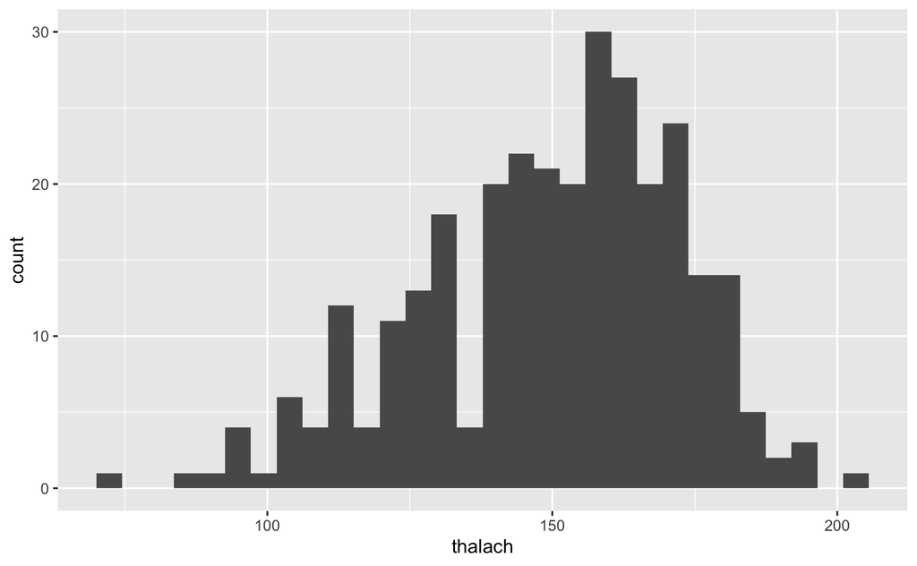

```r
heart_data %>%
  ggplot(aes(x = thalach)) +
  geom_histogram()
```

3. Also plot a barplot of exang (whether the patient displayed exercise induced angina)

```r
heart_data %>%
  ggplot() +
  geom_bar(aes(x = exang))

# this is very uneven -
```

[output not shown]

4. Now calculate population parameters: what is the mean thalach in the population. What proportion of patients have exercise induced angina (exang)?

| mean_thalach | prop_exang |
| --- | --- |
| 149.6469 | 0.3267327 |

5. Now take a single sample of 50-patients from the population and calculate point estimates for mean thalach and proportion of exang from this sample (let’s call these mean_thalach and prop_exang going forward). [Hint - use rep_sample_n() from the infer package to do this]

```r
point_estimate_sample_50 <- heart_sample %>%
  ungroup() %>%
  summarise(mean_thalach = mean(thalach),
            prop_exang = sum(exang == 1) / n())
```

```
Error in ungroup(.) : object 'heart_sample' not found
```

6. What are the sampling errors of these point estimates? [Hint - remember a sampling error is defined as the difference between a point estimate drawn from a sample, and a population parameter]

[output not shown]

7. Now we’re going to repeatedly sample 50-patients from the population and build up sampling distributions for the mean_thalach and prop_exang point estimates. Take 5000 samples and store the sampling distributions in a variable rep_sample_50. [Hint - again, use rep_sample_n() to do this.]
8. Visualise the sampling distributions of mean_thalach and prop_exang as histograms. How normal do the sampling distributions look?

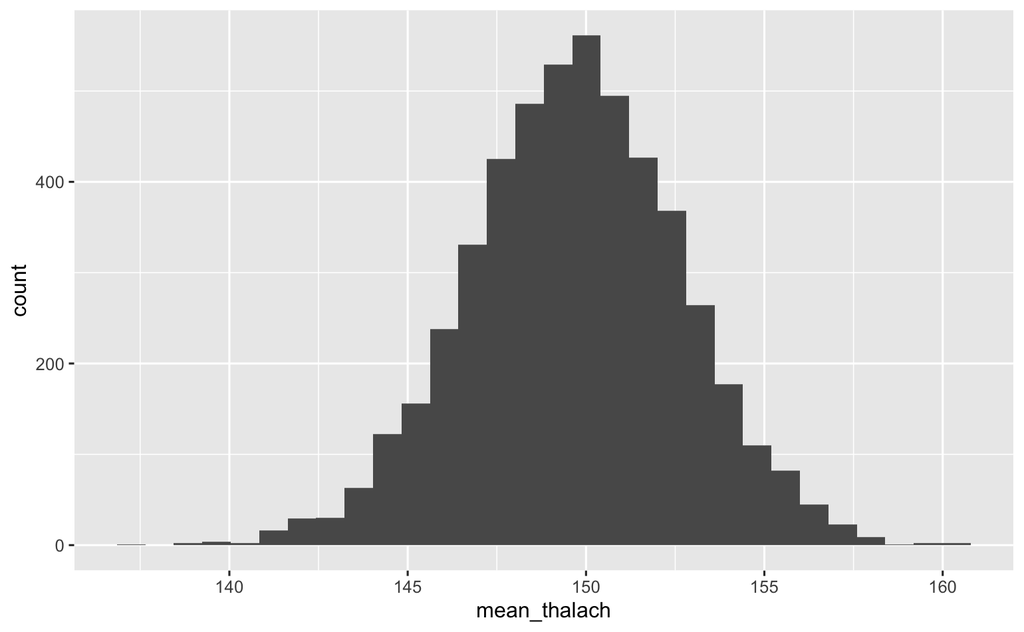

```r
heart_sample_50 %>%
  ggplot(aes(x = mean_thalach)) +
  geom_histogram()
```

9. Obtain standard errors of the sampling distribution of mean_thalach and prop_exang directly as the standard deviations of the sampling distributions held in rep_sample_50

```r
heart_sample_50 %>%
  summarise(sd_mean_thalach = sd(mean_thalach),
            sd_prop_exang = sd(prop_exang))
```

[output not shown]

[output not shown]